# Reanalysis: Testing the Kinship Theory of Intragenomic Conflict in Honey Bees

Sean Bresnahan

2023-04-04

Replicating pipeline and results described in [Galbraith et al. (2016). PNAS.](https://www.pnas.org/content/113/4/1020)

F1 Read counts and BED files of F0 variants are imported.

SNPs intersecting $n > 2$ genes, $n = 2$ genes with transcripts annotated on the same strand, or within mitochondrial, miRNA, or tRNA genes are discarded.

SNPs with $n < 10$ read counts in any cross; SNPs where the distance between the nearest SNP is shorter than the average read length (thus the read counts are exactly the same for both SNPs), and genes with $n < 2$ SNPs are discarded.

For each SNP, a Storer-Kim binomial exact test of two proportions is conducted to test the hypothesis that the proportion of maternal read counts is significantly different from the proportion of paternal read counts.

Previously established cutoffs for p1 (the proportion of “A” allele counts in individuals from the “EHBxAHB” cross) and p2 (the proportion of “A” allele counts in individuals from the “AHBxEHB” cross) are required for a gene to be considered as showing parent or lineage biased.

A GLIMMIX model [lmer(count~parent∗lineage+(1|SNP)+(1|individual))] is fit for each gene to assess the effects of parent, lineage, and their interaction, on the quantity of read counts at each SNP.

For a gene to be considered as showing parent or lineage biases, all SNPs are required to exhibit the same directional bias in both tests.

Genes exhibiting significant parent∗lineage effects are considered unbiased.

This analysis utilizes several custom functions. [See here for documentation.](https://github.com/sbresnahan/Galbraith-2016-PNAS-ASE-replication/blob/main/PSGE_functions_old.R)

# Requirements

```r
# Packages
library(tidyverse)
library(plyr)
library(Rfast)
library(tryCatchLog)
library(lmerTest)
library(car)
library(viridis)
library(gridExtra)
library(kableExtra)
library(gghalves)
library(ggdist)
library(ggpubr)
library(grid)
library(MASS)

# Custom functions
source("PSGE_functions_old.R")
```

# Setup

## Sample metadata

```r
metadata <- read.csv("metadata.csv")
kbl(metadata) %>% kable_styling()
```

| sample.id | parent | block | cross | phenotype | individual | lineage |
| --- | --- | --- | --- | --- | --- | --- |
| X8754AQ | Q | 1 | B | reproductive | X8754 | EHB |
| X875cAQ | Q | 1 | B | reproductive | X875c | EHB |
| X875gAQ | Q | 1 | B | reproductive | X875g | EHB |
| X8820AQ | Q | 2 | B | reproductive | X8820 | EHB |
| X882cAQ | Q | 2 | B | reproductive | X882c | EHB |
| X882pAQ | Q | 2 | B | reproductive | X882p | EHB |
| X888aAQ | Q | 1 | A | reproductive | X888a | AHB |
| X888hAQ | Q | 1 | A | reproductive | X888h | AHB |
| X888jAQ | Q | 1 | A | reproductive | X888j | AHB |
| X894bAQ | Q | 2 | A | reproductive | X894b | AHB |
| X894qAQ | Q | 2 | A | reproductive | X894q | AHB |
| X894rAQ | Q | 2 | A | reproductive | X894r | AHB |
| X8751IQ | Q | 1 | B | sterile | X8751 | EHB |
| X8756IQ | Q | 1 | B | sterile | X8756 | EHB |
| X875aIQ | Q | 1 | B | sterile | X875a | EHB |
| X8827IQ | Q | 2 | B | sterile | X8827 | EHB |
| X882gIQ | Q | 2 | B | sterile | X882g | EHB |
| X882kIQ | Q | 2 | B | sterile | X882k | EHB |
| X882mIQ | Q | 2 | B | sterile | X882m | EHB |
| X888eIQ | Q | 1 | A | sterile | X888e | AHB |
| X888qIQ | Q | 1 | A | sterile | X888q | AHB |
| X888uIQ | Q | 1 | A | sterile | X888u | AHB |
| X894cIQ | Q | 2 | A | sterile | X894c | AHB |
| X894fIQ | Q | 2 | A | sterile | X894f | AHB |
| X894iIQ | Q | 2 | A | sterile | X894i | AHB |
| X8754AD | D | 1 | B | reproductive | X8754 | EHB |
| X875cAD | D | 1 | B | reproductive | X875c | EHB |
| X875gAD | D | 1 | B | reproductive | X875g | EHB |
| X8820AD | D | 2 | B | reproductive | X8820 | EHB |
| X882cAD | D | 2 | B | reproductive | X882c | EHB |
| X882pAD | D | 2 | B | reproductive | X882p | EHB |
| X888aAD | D | 1 | A | reproductive | X888a | AHB |
| X888hAD | D | 1 | A | reproductive | X888h | AHB |
| X888jAD | D | 1 | A | reproductive | X888j | AHB |
| X894bAD | D | 2 | A | reproductive | X894b | AHB |
| X894qAD | D | 2 | A | reproductive | X894q | AHB |
| X894rAD | D | 2 | A | reproductive | X894r | AHB |
| X8751ID | D | 1 | B | sterile | X8751 | EHB |
| X8756ID | D | 1 | B | sterile | X8756 | EHB |
| X875aID | D | 1 | B | sterile | X875a | EHB |
| X8827ID | D | 2 | B | sterile | X8827 | EHB |
| X882gID | D | 2 | B | sterile | X882g | EHB |
| X882kID | D | 2 | B | sterile | X882k | EHB |
| X882mID | D | 2 | B | sterile | X882m | EHB |
| X888eID | D | 1 | A | sterile | X888e | AHB |
| X888qID | D | 1 | A | sterile | X888q | AHB |
| X888uID | D | 1 | A | sterile | X888u | AHB |
| X894cID | D | 2 | A | sterile | X894c | AHB |
| X894fID | D | 2 | A | sterile | X894f | AHB |
| X894iID | D | 2 | A | sterile | X894i | AHB |

## Load read counts at SNPs

```r
sterile_counts <- read.csv("sterile_counts.csv")
sterile_counts <- sterile_counts[!sterile_counts$ID==".",]
sterile_counts$SNP.gene <- paste(paste(sterile_counts$Chrm,
                                            sterile_counts$SNP.pos,sep="|"),
                                      sterile_counts$ID,sep=":")
row.names(sterile_counts) <- sterile_counts$SNP.gene
sterile_counts$SNP.gene <- NULL
sterile_counts$Chrm <- NULL
sterile_counts$SNP.pos <- NULL
sterile_counts$ID <- NULL

reproductive_counts <- read.csv("reproductive_counts.csv")
reproductive_counts <- reproductive_counts[!reproductive_counts$ID==".",]
reproductive_counts$SNP.gene <- paste(paste(reproductive_counts$Chrm,
                                            reproductive_counts$SNP.pos,sep="|"),
                                      reproductive_counts$ID,sep=":")
row.names(reproductive_counts) <- reproductive_counts$SNP.gene
reproductive_counts$SNP.gene <- NULL
reproductive_counts$Chrm <- NULL
reproductive_counts$SNP.pos <- NULL
reproductive_counts$ID <- NULL
```

## Filter SNPs

1. Remove rows with 0 counts by cross
2. Remove rows with > 10000 read counts (cannot run SK test on these)
3. Remove genes with < 2 SNPs

```r
sterile_counts <- filter.SNPs(sterile_counts,metadata,1)
write.csv(sterile_counts,"EHBxAHB_sterile_counts.csv")
reproductive_counts <- filter.SNPs(reproductive_counts,metadata,1)
write.csv(reproductive_counts,"EHBxAHB_reproductive_counts.csv")
```

# Conduct statistical tests

At each SNP, conduct a Storer-Kim binomial exact test of two proportions to test whether there is a statistically significant difference in the proportion of maternal vs paternal read counts

For each transcript, fit a GLIMMIX model to determine whether there is a statistically significant effect of parent, lineage, or their interaction on read counts at all SNP positions across the transcript

## Conduct Storer-Kim test at each tx:SNP

```r
sterile.SK <- PSGE.SK(sterile_counts,metadata,"sterile")
write.csv(sterile.SK,"EHBxAHB_sterileSK.csv", row.names=F)

reproductive.SK <- PSGE.SK(reproductive_counts,metadata,"reproductive")
write.csv(reproductive.SK,"EHBxAHB_reproductiveSK.csv", row.names=F)
```

## Conduct GLIMMIX test for each transcript

```r
sterile.GLIMMIX <- PSGE.GLIMMIX(sterile_counts,metadata)
write.csv(sterile.GLIMMIX,"EHBxAHB_sterileGLIMMIX.csv", row.names=F)

reproductive.GLIMMIX <- PSGE.GLIMMIX(reproductive_counts,metadata)
write.csv(reproductive.GLIMMIX,"EHBxAHB_reproductiveGLIMMIX.csv", row.names=F)
```

# Assess test results for each gene

1. Split count matrices by cross and parent of origin for plotting
2. Set up a data.frame to plot %p1 and %p2 for each SNP
3. Join results of Storer-Kim tests
4. Join results of GLIMMIX models
5. Correct for multiple testing
6. For each gene, check whether all SNPs are biased in the same direction
7. Genes with parentXcross effects are flagged as unbiased

```r
sterile.plot <- PSGE.analysis(sterile_counts,"sterile",metadata,
                                   sterile.SK,sterile.GLIMMIX)
write.csv(sterile.plot,"EHBxAHB_sterile_PSGE.csv",row.names=F)

reproductive.plot <- PSGE.analysis(reproductive_counts,"reproductive",metadata,
                                 reproductive.SK,reproductive.GLIMMIX)
write.csv(reproductive.plot,"EHBxAHB_reproductive_PSGE.csv",row.names=F)
```

# Plot results

1. Collapse SNPs to calculate p1 & p2 by transcript
2. Plot PSGE for each phenotype by transcript
3. Make center table and conduct chi-squared tests
4. Combine plots from steps 2 & 3 to generate final plot

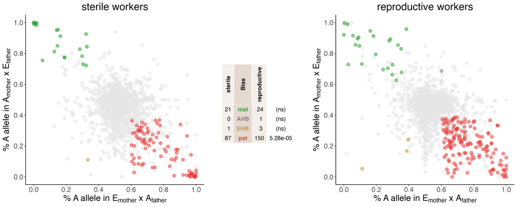